# R Lab 8 Key

## Setting Up

Kurtosis describes the tail shape of the data distribution. The normal distribution has zero excess kurtosis and thus the standard tail shape. It is said to be mesokurtic. Negative excess kurtosis would indicate a thin-tailed data distribution, and is said to be platykurtic. Positive excess kurtosis would indicate a fat-tailed distribution, and is said to be leptokurtic.

### Libraries

```r
library(tidyverse)
library(ggplot2)
library(psych)
library(viridis)
library(e1071)
```

## Data: Awards data set

The number of awards earned by students at one high school. Predictors of the number of awards earned include the type of program in which the student was enrolled (e.g., vocational, general or academic) and the score on their final exam in math. This data set is used to show an example of the Poisson Regression. The predicted variable is the number of awards and the predictors are the program type and the Maths score

```r
awards <- read.csv("../Data/Awards_R.csv")
glimpse(awards)
```

```
## Rows: 200
## Columns: 4
## $ id         <int> 45, 108, 15, 67, 153, 51, 164, 133, 2, 53, 1, 128, 16, 106,…
## $ num_awards <int> 1, 1, 1, 1, 1, 1, 1, 1, 1, 1, 1, 0, 1, 1, 1, 1, 1, 0, 1, 0,…
## $ prog       <int> 3, 1, 3, 3, 3, 1, 3, 3, 3, 3, 3, 2, 3, 3, 3, 1, 1, 3, 2, 3,…
## $ math       <int> 41, 41, 44, 42, 40, 42, 46, 40, 33, 46, 40, 38, 44, 37, 40,…
```

### EXERCISE 1: Number Awards Graph

In the code chunk below, use `geom_density()` to plot the distribution of `num_awards` in the `awards` dataset. Inside of `geom_density()`, set `alpha = .5`, and `fill =` to a color of your choice. Add a `geom_vline` in the color red that represents the mean `num_awards`. Finally, make sure you add a theme.

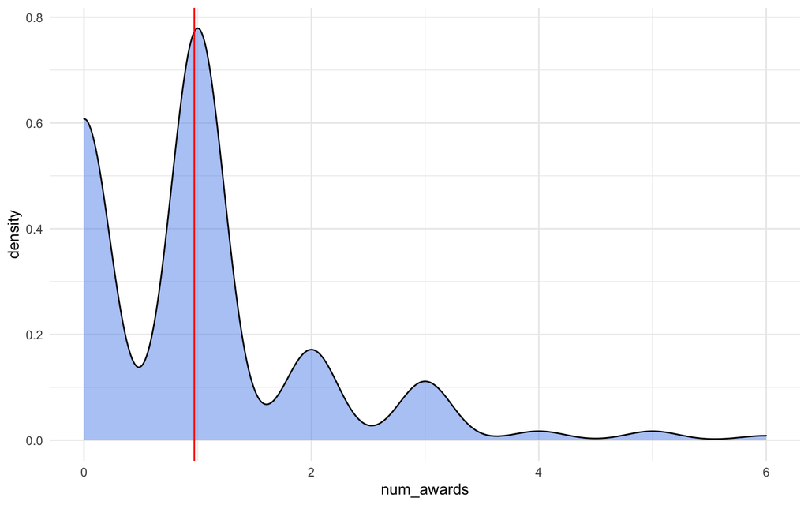

```r
ggplot(awards, aes(num_awards)) +
  geom_density( alpha = .5, fill = "cornflowerblue") +
  geom_vline(xintercept = mean(awards$num_awards), color = "red") +
  theme_minimal()
```

### EXERCISE 2: Number Awards Graph Interpretation

Describe the distribution you see in the graph from exercise 1. **Right-skewed**.

### EXERCISE 3: Number Awards Kurtosis

Use the `kurtosis()` function on `num_awards` and interpret the output: is it relatively meso-, platy-, or lepto- kurtic?

```r
kurtosis(awards$num_awards)
```

```
## [1] 3.854147
```

**Leptokurtic**

### EXERCISE 4: Math Performance Graph

In the code chunk below, use `geom_density()` to plot the distribution of `math` in the `awards` dataset. Inside of `geom_density()`, set `alpha = .5`, and `fill =` to a color of your choice. Add a `geom_vline` in the color red that represents the mean `math`. Finally, make sure you add a theme.

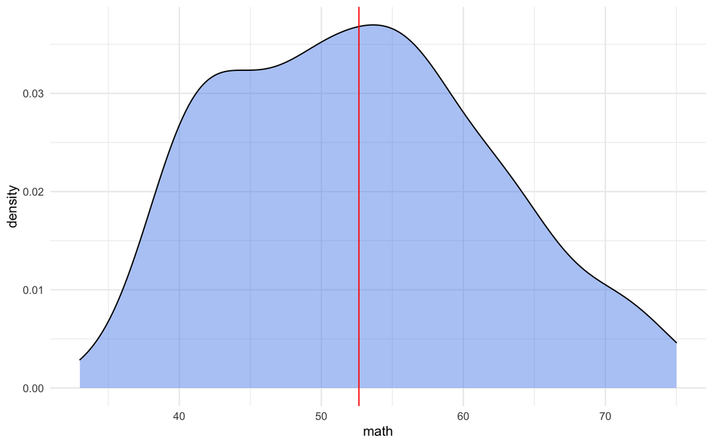

```r
ggplot(awards, aes(math)) +
  geom_density(alpha = .5, fill = "cornflowerblue") +
  geom_vline(xintercept = mean(awards$math), color = "red") +
  theme_minimal()
```

### EXERCISE 6: Math Performance Kurtosis

Use the `kurtosis()` function on `math` and interpret the output: is it relatively meso-, platy-, or lepto- kurtic?

```r
kurtosis(awards$math)
```

```
## [1] -0.6859955
```

Essentially meso-, but slightly platy-kurtic.

## Birthweight reduced data set

This dataset contains information on new born babies and their parents.

```r
birth <- read.csv("../Data/Birthweight_reduced_kg_R.csv")
glimpse(birth)
```

```
## Rows: 42
## Columns: 16
## $ ID          <int> 1360, 1016, 462, 1187, 553, 1636, 820, 1191, 1081, 822, 16…
## $ Length      <int> 56, 53, 58, 53, 54, 51, 52, 53, 54, 50, 53, 51, 52, 53, 53…
## $ Birthweight <dbl> 4.55, 4.32, 4.10, 4.07, 3.94, 3.93, 3.77, 3.65, 3.63, 3.42…
## $ Headcirc    <int> 34, 36, 39, 38, 37, 38, 34, 33, 38, 35, 33, 36, 36, 33, 34…
## $ Gestation   <int> 44, 40, 41, 44, 42, 38, 40, 42, 38, 38, 41, 40, 38, 41, 40…
## $ smoker      <int> 0, 0, 0, 0, 0, 0, 0, 0, 0, 0, 0, 0, 0, 0, 0, 0, 0, 0, 0, 0…
## $ mage        <int> 20, 19, 35, 20, 24, 29, 24, 21, 18, 20, 27, 24, 31, 21, 29…
## $ mnocig      <int> 0, 0, 0, 0, 0, 0, 0, 0, 0, 0, 0, 0, 0, 0, 0, 0, 0, 0, 0, 0…
## $ mheight     <int> 162, 171, 172, 174, 175, 165, 157, 165, 172, 157, 164, 168…
## $ mppwt       <int> 57, 62, 58, 68, 66, 61, 50, 61, 50, 48, 62, 53, 57, 55, 60…
## $ fage        <int> 23, 19, 31, 26, 30, 31, 31, 21, 20, 22, 37, 29, 35, 25, 30…
## $ fedyrs      <int> 10, 12, 16, 14, 12, 16, 16, 10, 12, 14, 14, 16, 16, 14, 16…
## $ fnocig      <int> 35, 0, 25, 25, 0, 0, 0, 25, 7, 0, 0, 0, 0, 25, 25, 0, 0, 2…
## $ fheight     <int> 179, 183, 185, 189, 184, 180, 173, 185, 172, 179, 170, 181…
## $ lowbwt      <int> 0, 0, 0, 0, 0, 0, 0, 0, 0, 0, 0, 0, 0, 0, 0, 0, 0, 0, 0, 1…
## $ mage35      <int> 0, 0, 1, 0, 0, 0, 0, 0, 0, 0, 0, 0, 0, 0, 0, 0, 0, 0, 0, 0…
```

### EXERCISE 7: Number of Cigarettes

Below, create a new variable inside the `birth` dataset called `z.mnocig`. To add it to the dataset, you will need to use `birth$z.mnocig <-` and assign it a value. Use the `scale()` function to add the z-scored version of `mnocig`, which is the mean number of daily cigarettes.

```r
birth$z.mnocig <- scale(birth$mnocig)
```

### EXERCISE 8: Mother’s Age

Below, create a new variable inside the `birth` dataset called `z.mage`. To add it to the dataset, you will need to use `birth$z.mage <-` and assign it a value. Use the `scale()` function to add the z-scored version of `mage`, which is the age of the mother.

```r
birth$z.mage <- scale(birth$mage)
```

### EXERCISE 9: Number of Cigarettes & Mother’s Age

Below, create a new variable inside the `birth` dataset called `z.combo`. To add it to the dataset, you will need to use `birth$z.combo <-` and assign it a value. Assign it the value of adding together the newly created `birth$z.mage` & `birth$z.mnocig` variables. Higher values (being above the mean) reflect being at higher risk for low birth weight.

```r
birth$z.combo <- birth$z.mnocig + birth$z.mage
```

### EXERCISE 10: Graphing Number of Cigarettes & Mother’s Age

In the code chunk below, use `geom_histogram()` to plot the distribution of `z.combo` in the `birth` dataset. Inside of `geom_histogram()`, set `bins = 10`, `alpha = .5`, and `fill =` to a color of your choice. Add a `geom_vline` in the color red that represents the mean `z.combo`, which is 0. Finally, make sure you add a theme.

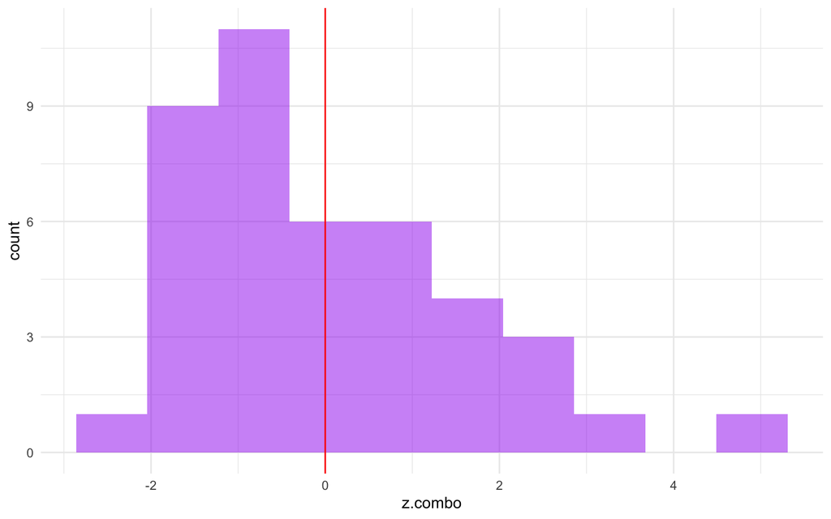

```r
ggplot(birth, aes(z.combo)) +
  geom_histogram(bins = 10, alpha = 0.5, fill = "purple") +
  geom_vline(xintercept = 0, color = "red") +
  theme_minimal()
```

### EXERCISE 11: Interpret Number of Cigarettes & Mother’s Age

What do you takeaway from the histogram in exercise 10?